# PV Power Lookup: PV1 & PV2

Erick Chauke

For PV1 and PV2, this notebook builds a lookup table from the measured grid (no fitting, no statistical model) and shows a few ways to look at the same data: a heatmap, a 3D surface, the table itself, and a nearest-measurement lookup function that answers "given this irradiance and module temperature, what did we actually measure closest to that?"

## Setup

```python
import sys
sys.path.insert(0, "../src")

import numpy as np
import pandas as pd
import matplotlib.pyplot as plt
from mpl_toolkits.mplot3d import Axes3D  # enables the 3D plot below
from grid_lookup import parse_grid_sheet, grid_to_table, nearest_lookup

DATA_PATH = "../data/FPCs.xlsm"
CAPACITY_MW = {"PV1": 75.0, "PV2": 75.0}
```

## PV1

```python
_, x_axis_pv1, y_axis_pv1, grid_pv1 = parse_grid_sheet(DATA_PATH, "PV1")
table_pv1 = grid_to_table(x_axis_pv1, y_axis_pv1, grid_pv1, "module_temp", "irradiance")
print(f"PV1: {len(table_pv1)} measured cells out of {grid_pv1.size}")
```

```
PV1: 298 measured cells out of 560
```

### Heatmap

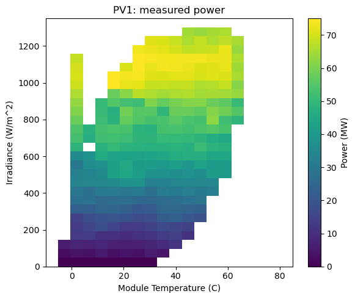

```python
fig, ax = plt.subplots(figsize=(6, 5))
im = ax.imshow(
    grid_pv1, origin="lower", aspect="auto",
    extent=[x_axis_pv1.min(), x_axis_pv1.max(), y_axis_pv1.min(), y_axis_pv1.max()],
    vmin=0, vmax=CAPACITY_MW["PV1"],
)
ax.set_xlabel("Module Temperature (C)")
ax.set_ylabel("Irradiance (W/m^2)")
ax.set_title("PV1: measured power")
fig.colorbar(im, ax=ax, label="Power (MW)")
fig.tight_layout()
fig.savefig("../outputs/pv1_heatmap.png", dpi=150)
plt.show()
```

### 3D View

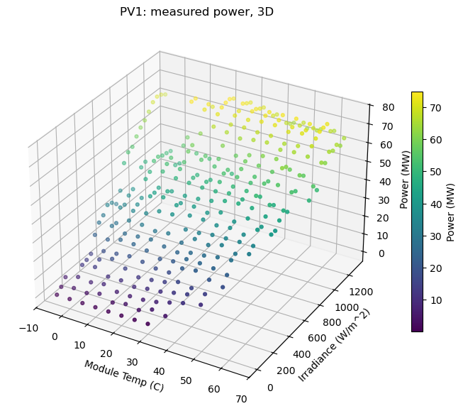

```python
fig = plt.figure(figsize=(7, 6))
ax = fig.add_subplot(111, projection="3d")
scatter = ax.scatter(table_pv1["module_temp"], table_pv1["irradiance"], table_pv1["power"],
                      c=table_pv1["power"], cmap="viridis", s=12)
ax.set_xlabel("Module Temp (C)")
ax.set_ylabel("Irradiance (W/m^2)")
ax.set_zlabel("Power (MW)")
ax.set_title("PV1: measured power, 3D")
fig.colorbar(scatter, ax=ax, label="Power (MW)", shrink=0.6)
fig.tight_layout()
fig.savefig("../outputs/pv1_3d_surface.png", dpi=150)
plt.show()
```

### The Lookup Table

The same data as the heatmap above, but as the actual table it is: one row per measured (irradiance, module temperature) combination. This is the whole "model", there is nothing computed here beyond what was already measured.

```python
print(table_pv1.sort_values(["irradiance", "module_temp"]).head(10).to_string(index=False))
print(f"... {len(table_pv1) - 10} more rows")
```

```
 irradiance  module_temp    power
        0.0         -5.0 0.124526
        0.0          0.0 0.032124
        0.0          5.0 0.061587
        0.0         10.0 0.059428
        0.0         15.0 0.015775
        0.0         20.0 0.048460
        0.0         25.0 0.083229
        0.0         30.0 0.196081
       50.0         -5.0 2.400000
       50.0          0.0 3.975197
... 288 more rows
```

### Looking Up a Value

Given an irradiance and module temperature that may or may not be exactly in the table, find the closest row already measured and use its power value.

```python
sample_queries_pv1 = [(800, 40), (500, 20), (1200, 60)]
for irradiance_query, temp_query in sample_queries_pv1:
    result = nearest_lookup(table_pv1, "module_temp", "irradiance",
                             x_query=temp_query, y_query=irradiance_query)
    print(f"Query: irradiance={irradiance_query} W/m^2, module_temp={temp_query} C  ->  "
          f"closest measurement: irradiance={result['irradiance']:.0f}, "
          f"module_temp={result['module_temp']:.0f}, power={result['power']:.2f} MW")
```

```
Query: irradiance=800 W/m^2, module_temp=40 C  ->  closest measurement: irradiance=800, module_temp=40, power=55.85 MW
Query: irradiance=500 W/m^2, module_temp=20 C  ->  closest measurement: irradiance=500, module_temp=20, power=43.98 MW
Query: irradiance=1200 W/m^2, module_temp=60 C  ->  closest measurement: irradiance=1200, module_temp=60, power=72.92 MW
```

## PV2

```python
_, x_axis_pv2, y_axis_pv2, grid_pv2 = parse_grid_sheet(DATA_PATH, "PV2")
table_pv2 = grid_to_table(x_axis_pv2, y_axis_pv2, grid_pv2, "module_temp", "irradiance")
print(f"PV2: {len(table_pv2)} measured cells out of {grid_pv2.size}")
```

```
PV2: 268 measured cells out of 560
```

### Heatmap

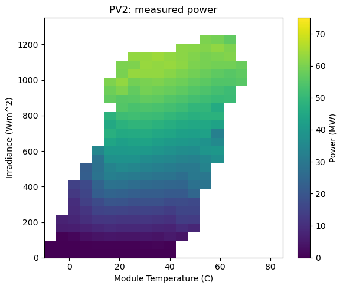

```python
fig, ax = plt.subplots(figsize=(6, 5))
im = ax.imshow(
    grid_pv2, origin="lower", aspect="auto",
    extent=[x_axis_pv2.min(), x_axis_pv2.max(), y_axis_pv2.min(), y_axis_pv2.max()],
    vmin=0, vmax=CAPACITY_MW["PV2"],
)
ax.set_xlabel("Module Temperature (C)")
ax.set_ylabel("Irradiance (W/m^2)")
ax.set_title("PV2: measured power")
fig.colorbar(im, ax=ax, label="Power (MW)")
fig.tight_layout()
fig.savefig("../outputs/pv2_heatmap.png", dpi=150)
plt.show()
```

### 3D View

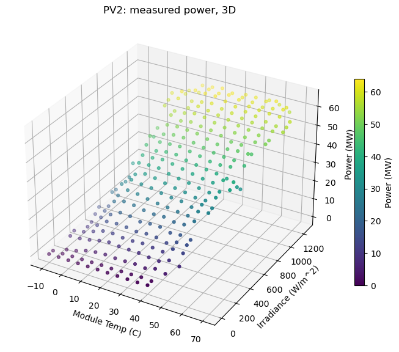

```python
fig = plt.figure(figsize=(7, 6))
ax = fig.add_subplot(111, projection="3d")
scatter = ax.scatter(table_pv2["module_temp"], table_pv2["irradiance"], table_pv2["power"],
                      c=table_pv2["power"], cmap="viridis", s=12)
ax.set_xlabel("Module Temp (C)")
ax.set_ylabel("Irradiance (W/m^2)")
ax.set_zlabel("Power (MW)")
ax.set_title("PV2: measured power, 3D")
fig.colorbar(scatter, ax=ax, label="Power (MW)", shrink=0.6)
fig.tight_layout()
fig.savefig("../outputs/pv2_3d_surface.png", dpi=150)
plt.show()
```

### The Lookup Table

The same data as the heatmap above, but as the actual table it is: one row per measured (irradiance, module temperature) combination. This is the whole "model", there is nothing computed here beyond what was already measured.

```python
print(table_pv2.sort_values(["irradiance", "module_temp"]).head(10).to_string(index=False))
print(f"... {len(table_pv2) - 10} more rows")
```

```
 irradiance  module_temp    power
        0.0        -10.0 0.000000
        0.0         -5.0 0.000000
        0.0          0.0 0.000373
        0.0          5.0 0.001532
        0.0         10.0 0.013450
        0.0         15.0 0.023434
        0.0         20.0 0.015278
        0.0         25.0 0.009657
        0.0         30.0 0.002996
        0.0         35.0 0.008275
... 258 more rows
```

### Looking Up a Value

Given an irradiance and module temperature that may or may not be exactly in the table, find the closest row already measured and use its power value.

```python
sample_queries_pv2 = [(800, 40), (500, 20), (1200, 60)]
for irradiance_query, temp_query in sample_queries_pv2:
    result = nearest_lookup(table_pv2, "module_temp", "irradiance",
                             x_query=temp_query, y_query=irradiance_query)
    print(f"Query: irradiance={irradiance_query} W/m^2, module_temp={temp_query} C  ->  "
          f"closest measurement: irradiance={result['irradiance']:.0f}, "
          f"module_temp={result['module_temp']:.0f}, power={result['power']:.2f} MW")
```

```
Query: irradiance=800 W/m^2, module_temp=40 C  ->  closest measurement: irradiance=800, module_temp=40, power=49.64 MW
Query: irradiance=500 W/m^2, module_temp=20 C  ->  closest measurement: irradiance=500, module_temp=20, power=35.17 MW
Query: irradiance=1200 W/m^2, module_temp=60 C  ->  closest measurement: irradiance=1200, module_temp=60, power=62.53 MW
```